# IODS course project

Let’s see what a linear regression can tell us about this.

```r
lm.BPRS1<- lm(bprs~week, data = BPRS)

summary(lm.BPRS1)
```

```
##
## Call:
## lm(formula = bprs ~ week, data = BPRS)
##
## Residuals:
##     Min      1Q  Median      3Q     Max
## -22.740  -8.740  -3.388   6.889  50.530
##
## Coefficients:
##             Estimate Std. Error t value Pr(>|t|)
## (Intercept)  46.7400     1.2003  38.940   <2e-16 ***
## week         -2.2704     0.2521  -9.005   <2e-16 ***
## ---
## Signif. codes:  0 '***' 0.001 '**' 0.01 '*' 0.05 '.' 0.1 ' ' 1
##
## Residual standard error: 12.35 on 358 degrees of freedom
## Multiple R-squared:  0.1847, Adjusted R-squared:  0.1824
## F-statistic:  81.1 on 1 and 358 DF,  p-value: < 2.2e-16
```

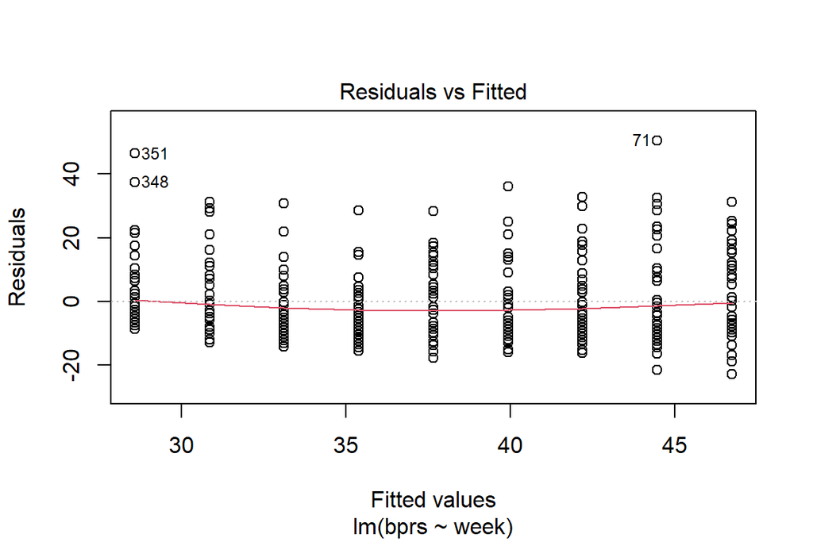

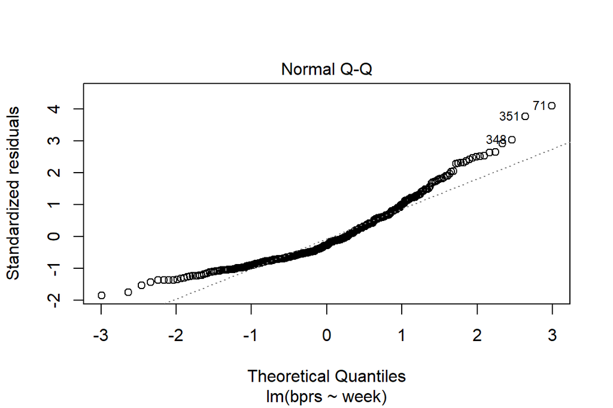

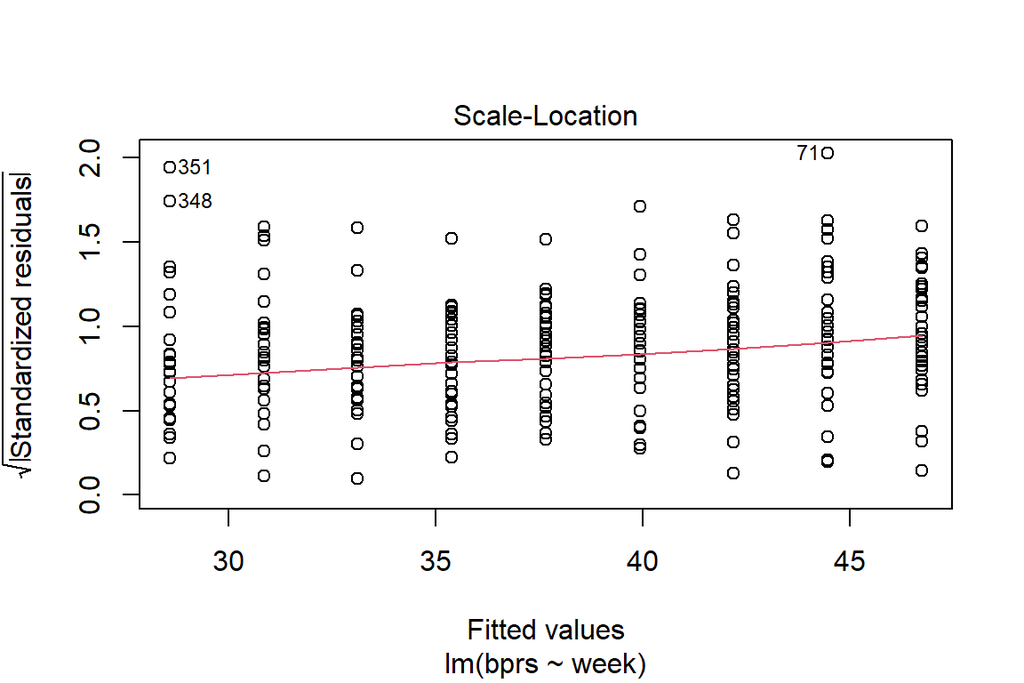

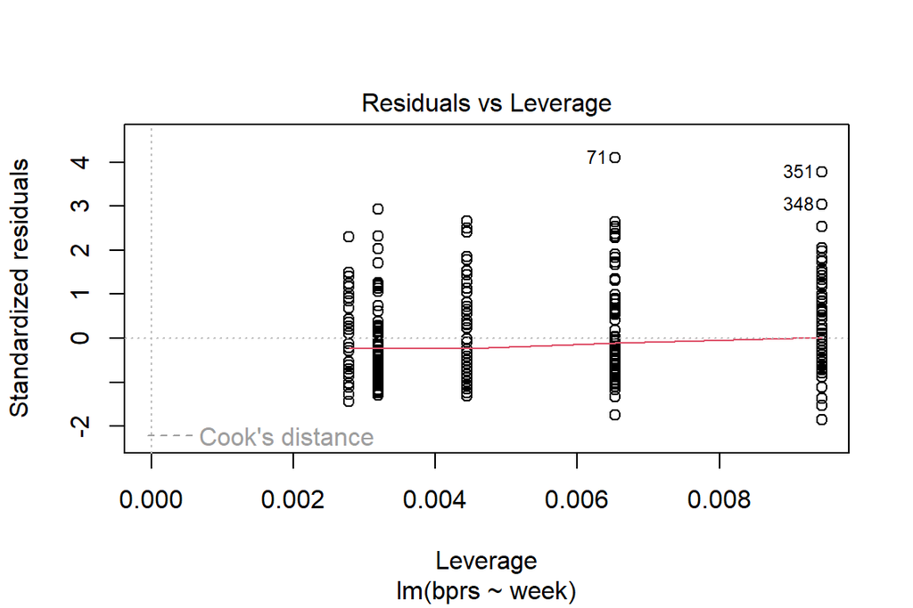

```r
plot(lm.BPRS1)
```

```r
anova(lm.BPRS1)
```

```
## Analysis of Variance Table
##
## Response: bprs
##            Df Sum Sq Mean Sq F value    Pr(>F)
## week        1  12372 12371.5  81.097 < 2.2e-16 ***
## Residuals 358  54613   152.6
## ---
## Signif. codes:  0 '***' 0.001 '**' 0.01 '*' 0.05 '.' 0.1 ' ' 1
```

So the week does appear to have a significant influence on the bprs.

Let’s give mixed modeling a try now

```r
library(lme4)
library(performance)

# Create a random intercept model
lmm.BPRS1 <- lmer(bprs ~ week + treatment + (1 | subject), data = BPRS, REML = FALSE)
summary(lmm.BPRS1)
```

```
## Linear mixed model fit by maximum likelihood  ['lmerMod']
## Formula: bprs ~ week + treatment + (1 | subject)
##    Data: BPRS
##
##      AIC      BIC   logLik deviance df.resid
##   2748.7   2768.1  -1369.4   2738.7      355
##
## Scaled residuals:
##     Min      1Q  Median      3Q     Max
## -3.0481 -0.6749 -0.1361  0.4813  3.4855
##
## Random effects:
##  Groups   Name        Variance Std.Dev.
##  subject  (Intercept)  47.41    6.885
##  Residual             104.21   10.208
## Number of obs: 360, groups:  subject, 20
##
## Fixed effects:
##             Estimate Std. Error t value
## (Intercept)  45.8817     2.4413  18.794
## week         -2.2704     0.2084 -10.896
## treatment     0.5722     1.0761   0.532
##
## Correlation of Fixed Effects:
##           (Intr) week
## week      -0.341
## treatment -0.661  0.000
```

```r
performance(lmm.BPRS1)
```

```
## # Indices of model performance
##
## AIC      |     AICc |      BIC | R2 (cond.) | R2 (marg.) |   ICC |  RMSE |  Sigma
## ---------------------------------------------------------------------------------
## 2745.198 | 2745.368 | 2764.629 |      0.440 |      0.186 | 0.313 | 9.953 | 10.208
```

As indicated by the “performance” function, the fixed effects (week and treatment) explain 18.6% of the variations in bprs (as indicated by marginal R2. But with the random effect, “subject”, as well, the model explains 44% of the variation (Conditional R2).

Let’s try another model without the treatment as a fixed effect.

```r
lmm.BPRS2 <- lmer(bprs ~ week +  (treatment | subject), data = BPRS, REML = FALSE)
summary(lmm.BPRS2)
```

```
## Linear mixed model fit by maximum likelihood  ['lmerMod']
## Formula: bprs ~ week + (treatment | subject)
##    Data: BPRS
##
##      AIC      BIC   logLik deviance df.resid
##   2582.8   2606.1  -1285.4   2570.8      354
##
## Scaled residuals:
##     Min      1Q  Median      3Q     Max
## -2.3026 -0.6034 -0.0675  0.4397  3.1714
##
## Random effects:
##  Groups   Name        Variance Std.Dev. Corr
##  subject  (Intercept) 376.73   19.410
##           treatment   189.16   13.754   -0.94
##  Residual              54.23    7.364
## Number of obs: 360, groups:  subject, 20
##
## Fixed effects:
##             Estimate Std. Error t value
## (Intercept)  46.6461     1.6586   28.12
## week         -2.2704     0.1503  -15.10
##
## Correlation of Fixed Effects:
##      (Intr)
## week -0.363
```

```r
performance(lmm.BPRS2)
```

```
## # Indices of model performance
##
## AIC      |     AICc |      BIC | R2 (cond.) | R2 (marg.) |   ICC |  RMSE | Sigma
## --------------------------------------------------------------------------------
## 2582.011 | 2582.249 | 2605.328 |      0.883 |      0.074 | 0.874 | 6.971 | 7.364
```

A random intercept and random slope give us a model with lower AIC. Let’s compare the two models using ANOVA now.

```r
anova(lmm.BPRS1)
```

```
## Analysis of Variance Table
##           npar  Sum Sq Mean Sq  F value
## week         1 12371.5 12371.5 118.7136
## treatment    1    29.5    29.5   0.2828
```

```r
anova(lmm.BPRS2)
```

```
## Analysis of Variance Table
##      npar Sum Sq Mean Sq F value
## week    1  12372   12372  228.14
```

```r
anova(lmm.BPRS1, lmm.BPRS2)
```

```
## Data: BPRS
## Models:
## lmm.BPRS1: bprs ~ week + treatment + (1 | subject)
## lmm.BPRS2: bprs ~ week + (treatment | subject)
##           npar    AIC    BIC  logLik deviance  Chisq Df Pr(>Chisq)
## lmm.BPRS1    5 2748.7 2768.1 -1369.4   2738.7
## lmm.BPRS2    6 2582.8 2606.1 -1285.4   2570.8 167.94  1  < 2.2e-16 ***
## ---
## Signif. codes:  0 '***' 0.001 '**' 0.01 '*' 0.05 '.' 0.1 ' ' 1
```

Let’s see if an interaction variable works better.

```r
lmm.BPRS3 <- lmer(bprs ~  week * treatment + (1 | subject), data = BPRS, REML = FALSE)
summary(lmm.BPRS3)
```

```
## Linear mixed model fit by maximum likelihood  ['lmerMod']
## Formula: bprs ~ week * treatment + (1 | subject)
##    Data: BPRS
##
##      AIC      BIC   logLik deviance df.resid
##   2747.7   2771.1  -1367.9   2735.7      354
##
## Scaled residuals:
##     Min      1Q  Median      3Q     Max
## -3.2038 -0.6641 -0.0846  0.4837  3.6049
##
## Random effects:
##  Groups   Name        Variance Std.Dev.
##  subject  (Intercept)  47.46    6.889
##  Residual             103.31   10.164
## Number of obs: 360, groups:  subject, 20
##
## Fixed effects:
##                Estimate Std. Error t value
## (Intercept)     50.1767     3.4828  14.407
## week            -3.3442     0.6561  -5.097
## treatment       -2.2911     1.9755  -1.160
## week:treatment   0.7158     0.4149   1.725
##
## Correlation of Fixed Effects:
##             (Intr) week   trtmnt
## week        -0.754
## treatment   -0.851  0.797
## week:trtmnt  0.715 -0.949 -0.840
```

```r
performance(lmm.BPRS3)
```

```
## # Indices of model performance
##
## AIC      |     AICc |      BIC | R2 (cond.) | R2 (marg.) |   ICC |  RMSE |  Sigma
## ---------------------------------------------------------------------------------
## 2744.164 | 2744.402 | 2767.481 |      0.445 |      0.190 | 0.315 | 9.909 | 10.164
```

```r
anova(lmm.BPRS3)
```

```
## Analysis of Variance Table
##                npar  Sum Sq Mean Sq  F value
## week              1 12371.5 12371.5 119.7527
## treatment         1    29.5    29.5   0.2853
## week:treatment    1   307.5   307.5   2.9760
```

Still no significant effect of the week*treatment

```r
anova(lmm.BPRS1,lmm.BPRS2,lmm.BPRS3)
```

```
## Data: BPRS
## Models:
## lmm.BPRS1: bprs ~ week + treatment + (1 | subject)
## lmm.BPRS2: bprs ~ week + (treatment | subject)
## lmm.BPRS3: bprs ~ week * treatment + (1 | subject)
##           npar    AIC    BIC  logLik deviance  Chisq Df Pr(>Chisq)
## lmm.BPRS1    5 2748.7 2768.1 -1369.4   2738.7
## lmm.BPRS2    6 2582.8 2606.1 -1285.4   2570.8 167.94  1  < 2.2e-16 ***
## lmm.BPRS3    6 2747.8 2771.1 -1367.9   2735.8   0.00  0
## ---
## Signif. codes:  0 '***' 0.001 '**' 0.01 '*' 0.05 '.' 0.1 ' ' 1
```

The second model remains the significant model out of the three mixed models.